# The Science of Decisions Project (Statistics)

Ada Lee

September 29, 2015

## Abstract

In this paper I use R to conduct a t-test on [stroop effect](https://en.wikipedia.org/wiki/Stroop_effect).

## Stroop dataset

```r
stroop <- read.csv('stroopdata.csv')
stroop
```

```
##    Congruent Incongruent
## 1     12.079      19.278
## 2     16.791      18.741
## 3      9.564      21.214
## 4      8.630      15.687
## 5     14.669      22.803
## 6     12.238      20.878
## 7     14.692      24.572
## 8      8.987      17.394
## 9      9.401      20.762
## 10    14.480      26.282
## 11    22.328      24.524
## 12    15.298      18.644
## 13    15.073      17.510
## 14    16.929      20.330
## 15    18.200      35.255
## 16    12.130      22.158
## 17    18.495      25.139
## 18    10.639      20.429
## 19    11.344      17.425
## 20    12.369      34.288
## 21    12.944      23.894
## 22    14.233      17.960
## 23    19.710      22.058
## 24    16.004      21.157
```

## Identify variables in the dataset

independent variable: Weather the word is the same as the color of the word (Congruent or Incongruent)

dependent variable: time takes to recognize color of words

## Plot the data

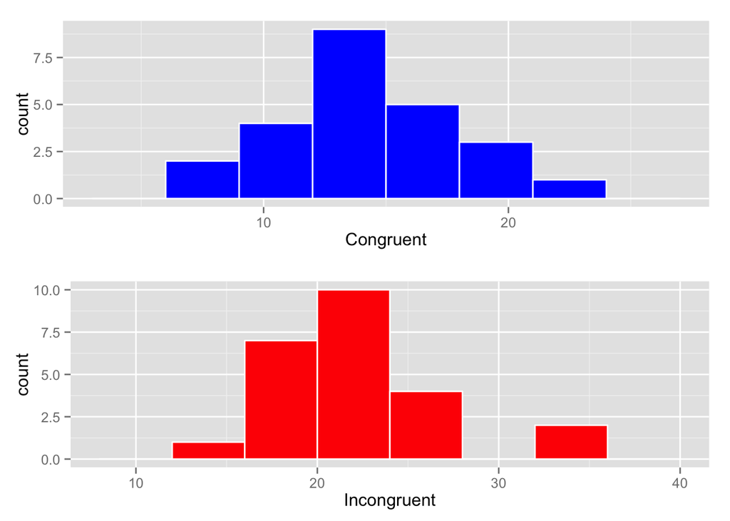

```r
library(ggplot2)
library(gridExtra)
p1 <- ggplot(aes(x=Congruent), data=stroop) + geom_histogram(fill='blue', color='white', binwidth=3)
p2 <- ggplot(aes(x=Incongruent), data=stroop) + geom_histogram(fill='red', color='white', binwidth=4)
grid.arrange(p1, p2)
```

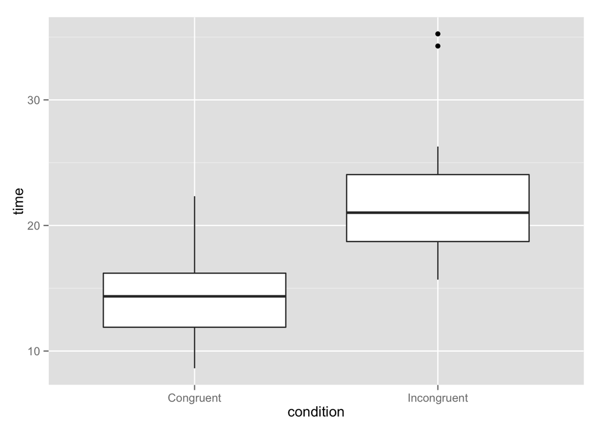

```r
stroop2 <- rbind(data.frame(time=stroop$Congruent, condition="Congruent"),
                 data.frame(time=stroop$Incongruent, condition="Incongruent"))
ggplot(aes(x=condition, y=time), data=stroop2) + geom_boxplot()
```

From histogram of Congruent time and Incongruent time we can see that the data is approximately normally distributed, from box plot we can see that most time in Incongruent group is greater than time in Congruent group.

## Report descriptive statistics

```r
Congruent.mean <- mean(stroop$Congruent) #14.05113
Incongruent.mean <- mean(stroop$Incongruent) #22.01592
sd.Congruent <- sd(stroop$Congruent) #3.559358
sd.Incongruent <- sd(stroop$Incongruent) #4.797057
```

Average time of Congruent group is 14.051, and average time of Incongruent group is 22.016, the latter is larger. The deviances are 3.559 and 4.797. The times in Incongruent group vary more.

## Establish a hypothesis and statistical test

Because time in both groups is approximately normal, we could conduct z-test or t-test for them, however we only have 24 datasets and we don’t know the population standard error, so z-test would not be appropriate for this dataset, thus I would use t-test. Our data come from 24 participants take two tests, one for congruent condition, another for incongruent condition, so I would use paired sample test. Since I care about whether time need to recognize color in Incongruent group is greater than that in Congruent group, I would use one-tailed test. In summary I would use one-tailed paired sample t-test for this dataset.

### Define $\mu_1$ and $\mu_2$

$\mu_1$: average of time population in Congruent group  
$\mu_2$: average of time population in Incongruent group

### Null hypothesis and alternative hypothesis

$H_0$: Average of time population in Incongruent group is less than or equal to average of time population in Congruent group ($\mu_2 \leq \mu_1$)

$H_a$: Average of time population in Incongruent group is greater than average of time population in Congruent group ($\mu_2 \gt \mu_1$)

## Perform t-test and interpret results

```r
n <- dim(stroop)[1] #24
diff <- Incongruent.mean - Congruent.mean #7.964792
s <- sd(stroop$Incongruent - stroop$Congruent) #4.864827
standard.error <- s / sqrt(n) #0.9930286
t.statistic <- diff / standard.error #8.020707
t.critical <- qt(.99, df=n-1) #2.499867
p.value <- 1 - pt(t.statistic, df=n-1) #2.0515e-08
```

T critical value for $\alpha = 0.01$ is 2.5, which is smaller than our t statistic value 8.02, so we reject the null hypothesis. We could also decide by looking p value, p value for this test is $2.05\times10^{-8}$, which is a lot smaller than $\alpha$. We reject the null hypothesis, thus we accept the alternative hypothesis, that is “Average of time population in Incongruent group is greater than average of time population in Congruent group”. This means that words do help people to recognize color in Congruent group or words do interfere people to recognize color in Incongruent group.

## Digging deeper

Although we get conclusion “Average of time population in Incongruent group is greater than average of time population in Congruent group”, actually we don’t know weather words help people to recognize color in Congruent group, or interfere people to recognize color in Incongruent group, or both. It would better have a neutral group to help us decide.